# Notebook

CICD-PROJECT Used Cars EDA

### **Problem Statement**

#### Business Context

An automobile dealership in Los Vegas specializes in selling luxury and non-luxury vehicles. They cater to diverse customer preferences with varying vehicle specifications, such as mileage, engine capacity, and seating capacity. However, the dealership faces significant challenges in maintaining consistency and efficiency across its pricing strategy due to reliance on manual processes and disconnected systems. Pricing evaluations are prone to errors, updates are delayed, and scaling operations are difficult as demand grows. These inefficiencies impact revenue and customer trust. Recognizing the need for a reliable and scalable solution, the dealership is seeking to implement a unified system that ensures seamless integration of data-driven pricing decisions, adaptability to changing market conditions, and operational efficiency.

#### Objective

The dealership has hired you as an MLOps Engineer to design and implement an MLOps pipeline that automates the pricing workflow. This pipeline will encompass data cleaning, preprocessing, transformation, model building, training, evaluation, and registration with CI/CD capabilities to ensure continuous integration and delivery. Your role is to overcome challenges such as integrating disparate data sources, maintaining consistent model performance, and enabling scalable, automated updates to meet evolving business needs. The expected outcomes are a robust, automated system that improves pricing accuracy, operational efficiency, and scalability, driving increased profitability and customer satisfaction.

#### Data Description

The data contains the different data related to a Used Cars. The detailed data dictionary is given below.

#### Data Dictionary

Segment: Describes the category of the vehicle, indicating whether it is a luxury or non-luxury segment.

Kilometers_Driven: The total number of kilometers the vehicle has been driven.

Mileage: The fuel efficiency of the vehicle, measured in kilometers per liter (km/l).

Engine: The engine capacity of the vehicle, measured in cubic centimeters (cc).

Power: The power of the vehicle's engine, measured in brake horsepower (BHP).

Seats: The number of seats in the vehicle, can influence the vehicle's classification, usage, and pricing based on customer needs.

Price: The price of the vehicle, listed in lakhs (units of 100,000), represents the cost to the consumer for purchasing the vehicle.

### **Importing the necessary libraries**

```python
import warnings
warnings.simplefilter(action="ignore", category=FutureWarning)
```

```python
%pip install seaborn
```

```
Downloading seaborn-0.13.2-py3-none-any.whl (294 kB)
```

```python
# import libraries for data manipulation
import numpy as np
import pandas as pd

# import libraries for data visualization
import matplotlib.pyplot as plt
import seaborn as sns
```

### **Loading the datset**

```python
# read the data
df = pd.read_csv('used_cars.csv')
# returns the first 5 rows
df.head()
```

|  | Segment | Kilometers_Driven | Mileage | Engine | Power | Seats | price |
| --- | --- | --- | --- | --- | --- | --- | --- |
| 0 | non-luxury segment | 72000 | 26.60 | 998 | 58.16 | 5 | 5.51 |
| 1 | non-luxury segment | 41000 | 19.67 | 1582 | 126.20 | 5 | 16.06 |
| 2 | non-luxury segment | 46000 | 18.20 | 1199 | 88.70 | 5 | 8.61 |
| 3 | non-luxury segment | 87000 | 20.77 | 1248 | 88.76 | 7 | 11.27 |
| 4 | non-luxury segment | 75000 | 21.10 | 814 | 55.20 | 5 | 10.25 |

**Observations:**

The DataFrame has 7 columns as mentioned in the Data Dictionary. Data in each row corresponds to a used car sale.

### **Data Overview**

#### How many rows and columns are present in the data?

```python
# check the shape of the dataset
df.shape
```

```
(200, 7)
```

**Observations:**

- The DataFrame has 200 rows and 7 columns.

#### What are the datatypes of the different columns in the dataset? (The info() function can be used).

```python
# use info() to print a concise summary of the DataFrame
df.info()
```

```
<class 'pandas.core.frame.DataFrame'>
RangeIndex: 200 entries, 0 to 199
Data columns (total 7 columns):
 #   Column             Non-Null Count  Dtype
---  ------             --------------  -----
 0   Segment            200 non-null    object
 1   Kilometers_Driven  200 non-null    int64
 2   Mileage            200 non-null    float64
 3   Engine             200 non-null    int64
 4   Power              200 non-null    float64
 5   Seats              200 non-null    int64
 6   price              200 non-null    float64
dtypes: float64(3), int64(3), object(1)
memory usage: 11.1+ KB
```

**Observations:**

The DataFrame contains 200 rows and 7 columns, providing a reasonably small but manageable sample for exploratory analysis.

All features are complete (no missing values), which means we do not need initial imputation or row-dropping for null handling.

There is 1 categorical feature ('Segment') stored as object dtype and 6 numerical features (3 int64, 3 float64), giving a good mix for both statistical and visual EDA.

The numeric columns ('Kilometers_Driven', 'Mileage', 'Engine', 'Power', 'Seats', 'price') are suitable for correlation analysis and regression-style modelling, with 'price' acting as the target variable.

The memory footprint is very small (~11.1 KB), so performance constraints are negligible and we can freely compute descriptive statistics and visualizations on the full dataset.

#### Are there any missing values in the data? If yes, treat them using an appropriate method.

```python
# Checking for missing values
df.isnull().sum()
```

```
Segment              0
Kilometers_Driven    0
Mileage              0
Engine               0
Power                0
Seats                0
price                0
dtype: int64
```

**Observations:**

- There are no missing values in the data.

```python
# get the summary statistics of the numerical data
df.describe()
```

|  | Kilometers_Driven | Mileage | Engine | Power | Seats | price |
| --- | --- | --- | --- | --- | --- | --- |
| count | 200.000000 | 200.000000 | 200.000000 | 200.000000 | 200.000000 | 200.000000 |
| mean | 56216.320000 | 17.267550 | 1830.265000 | 139.476600 | 5.210000 | 34.893275 |
| std | 32439.964218 | 4.683883 | 687.191447 | 70.907139 | 0.780349 | 31.458322 |
| min | 8350.000000 | 0.000000 | 624.000000 | 35.000000 | 2.000000 | 4.360000 |
| 25% | 34997.500000 | 14.370000 | 1248.000000 | 82.887500 | 5.000000 | 9.870000 |
| 50% | 54000.000000 | 17.110000 | 1874.500000 | 126.260000 | 5.000000 | 19.102500 |
| 75% | 71316.000000 | 20.360000 | 2143.000000 | 177.002500 | 5.000000 | 53.140000 |
| max | 262000.000000 | 28.400000 | 5461.000000 | 500.000000 | 8.000000 | 136.000000 |

**Observations:**

- Summary statistics show 200 observations for each feature, confirming a complete dataset with no missing numeric values.
- Kilometers_Driven has a mean around 56k km with a wide spread (std ≈ 32k) and a max of 262k km, indicating a mix of lightly used and heavily used cars and likely right-skewed usage.
- Mileage ranges from 0 to about 28.4, with median ≈ 17.1 and IQR roughly 14.4–20.4, suggesting most cars cluster around moderate fuel efficiency while a few very low/high mileage values may act as outliers or data quality flags (e.g., 0).
- Engine size (mean ≈ 1830 cc, max 5461 cc) and Power (mean ≈ 139 bhp, max 500 bhp) both show large ranges, implying heterogeneous vehicle segments from compact cars to high-performance models; this variation should strongly influence price.
- Seats is tightly concentrated around 5 (median and 75th percentile both 5), with a minimum of 2 and max of 8, indicating that 5-seater cars dominate and higher seating capacity is relatively rare.
- Price shows strong dispersion (mean ≈ 34.9, std ≈ 31.5, max 136) with median around 19.1, so the distribution is right-skewed: most cars are in a lower price band, with a smaller number of high-priced vehicles pulling up the mean.
- Overall, the statistics suggest non-normal, right-skewed distributions in key variables (Kilometers_Driven, Power, price), so log or other transformations and robust metrics may be useful before fitting regression models.

#### How many cars have 0 mileage?

```python
(df["Mileage"] == 0).sum()
```

```
3
```

**Observations:**

- There are 3 cars that show 0 mileage

### **Univariate Analysis**

#### Explore all the variables and provide observations on their distributions. (Generally, histograms, boxplots, countplots, etc. are used for univariate exploration.)

```python
# check unique segments
df['Segment'].nunique()
```

```
2
```

**Observations:**

- There are 2 unique Segments, either Luxury or Non-Luxury

##### Seats

```python
# check unique seat counts
df['Seats'].nunique()
```

```
6
```

**Observations:**

- There are 6 unique Seat counts

```python
df['Seats'].value_counts()
```

```
5    167
7     19
4      7
8      4
6      2
2      1
Name: Seats, dtype: int64
```

**Observations:**

- 5-seaters comprise the vast majority of used cars sold.

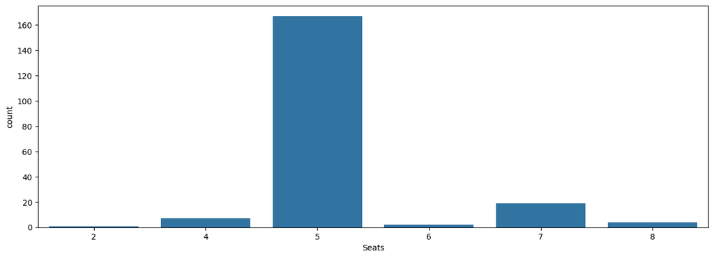

```python
plt.figure(figsize = (15,5))
sns.countplot(data = df, x = 'Seats');
```

##### Kilometers Driven

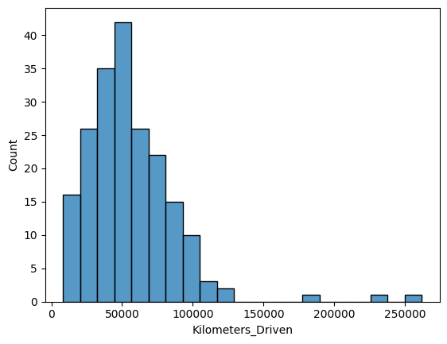

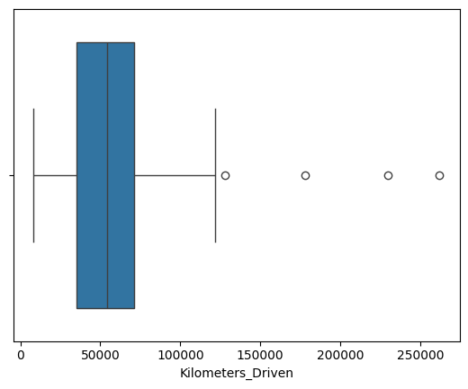

```python
sns.histplot(data=df,x='Kilometers_Driven')
plt.show()
sns.boxplot(data=df,x='Kilometers_Driven')
plt.show()
```

**Observations:**

- Kilometers_Driven shows a right-skewed distribution in the histogram: most cars cluster between roughly 20k and 80k km, while a small number extend beyond 150k–250k km, indicating a mix of moderately used and heavily used vehicles.
- The boxplot confirms several high-mileage outliers well above the upper whisker, suggesting that these cars have significantly more usage than the typical vehicle in the dataset and may warrant special treatment (e.g., capping or separate analysis).
- The central box is relatively narrow compared to the full range, meaning the middle 50% of cars have similar mileage, and most variability is driven by a minority of very high-mileage observations.

##### Mileage

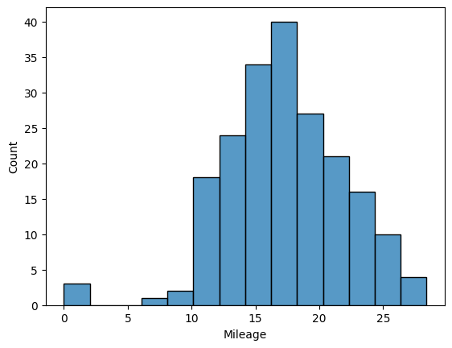

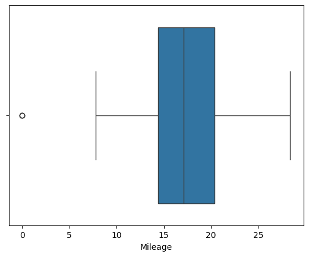

```python
sns.histplot(data=df,x='Mileage')
plt.show()
sns.boxplot(data=df,x='Mileage')
plt.show()
```

##### Engine

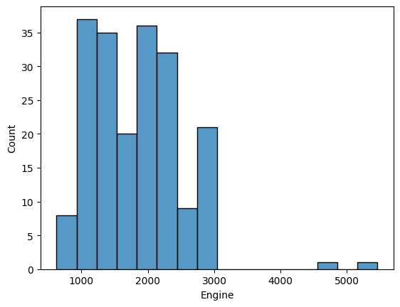

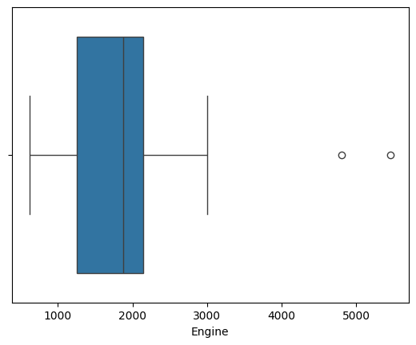

```python
sns.histplot(data=df,x='Engine')
plt.show()
sns.boxplot(data=df,x='Engine')
plt.show()
```

**Observations:**

- The engine-size histogram shows most cars have engines between roughly 1,000 cc and 3,000 cc, indicating the dataset is dominated by small to mid-sized vehicles.
- There are a few cars with much larger engines (around 4,500–5,500 cc), which appear as clear outliers in both the histogram and boxplot and likely correspond to high-performance or luxury models.
- The boxplot suggests the central 50% of cars are fairly tightly clustered around typical engine sizes, while the extreme large-engine outliers could have a disproportionate effect on price and may require special handling (e.g., transformation or separate segment analysis).

##### Power

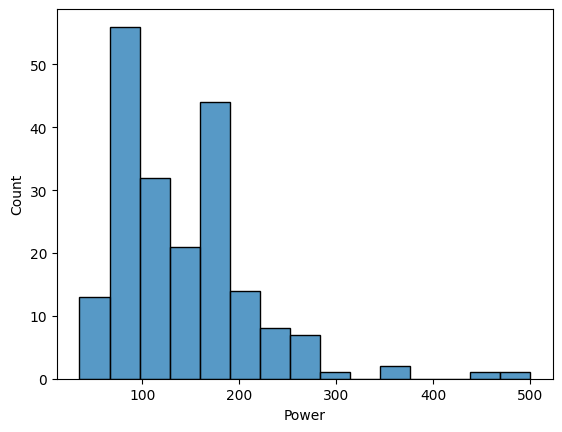

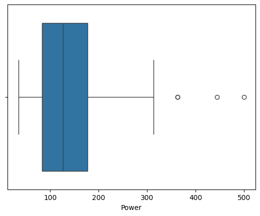

```python
sns.histplot(data=df,x='Power')
plt.show()
sns.boxplot(data=df,x='Power')
plt.show()
```

**Observations:**

- The power histogram shows most cars concentrated between roughly 80 and 220 bhp, suggesting the dataset is dominated by average-performance vehicles rather than very low- or very high-powered cars.
- There are a few cars with substantially higher power (around 300–500 bhp) that appear as clear outliers in both the histogram and boxplot, likely representing sports or premium models that may command much higher prices.
- The boxplot indicates a moderately wide interquartile range, so there is meaningful variation in engine power among typical cars, but the extreme high-power outliers could strongly influence correlations with price and may benefit from transformation or segmented modeling.

##### Price

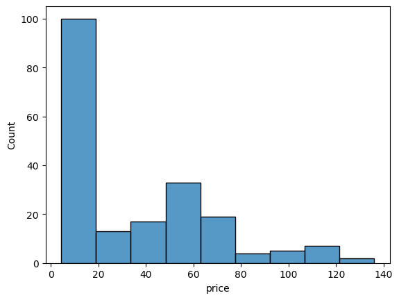

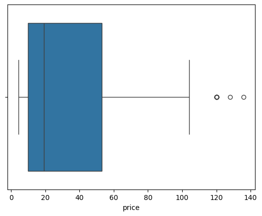

```python
sns.histplot(data=df,x='price')
plt.show()
sns.boxplot(data=df,x='price')
plt.show()
```

```python
# Get cars that price above 100,000 lahks
df_greater_than_100 = df[df['price'] > 100]

# Calculate the number of total cars where the price above 100,000 lahks

print('The number of total care that cost above 100,000 lahks is:', df_greater_than_100.shape[0])

# Calculate percentage of such price in the dataset
percentage = (df_greater_than_100.shape[0] / df.shape[0]) * 100

print("Percentage of cars priced above 100,000 lahks:", round(percentage, 2), '%')
```

```
The number of total care that cost above 100,000 lahks is: 12
Percentage of cars priced above 100,000 lahks: 6.0 %
```

#### What is the mean mileage driven?

```python
# get the mean mileage driven
print('The mean mileage driven for this dataset is', round(df['Kilometers_Driven'].mean(), 2), 'kilometers')
```

```
The mean mileage driven for this dataset is 56216.32 kilometers
```

**Observations:**

- The mean mileage driven for this dataset is 56216.32 kilometers

### **Multivariate Analysis**

#### Perform a multivariate analysis to explore relationships between the important variables in the dataset. (It is a good idea to explore relations between numerical variables as well as relations between numerical and categorical variables)

##### Segment vs Price of the Car

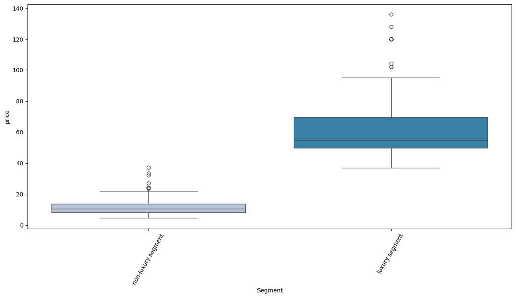

```python
# Relationship between price of the car and segment
plt.figure(figsize=(15,7))
sns.boxplot(x = "Segment", y = "price", data = df, palette = 'PuBu')
plt.xticks(rotation = 60)
plt.show()
```

**Observations:**

- The boxplot shows a clear price separation between segments: luxury cars have a much higher median price than non‑luxury cars, confirming Segment is a strong driver of price differentiation.
- Non‑luxury prices are tightly clustered with a low IQR and relatively few high‑price outliers,indicating a fairly homogeneous mass‑market segment.
- Luxury prices exhibit a wider IQR and several extreme high‑price outliers, suggesting substantial variability within the luxury segmentand the presence of ultra‑premium models that could heavily influence model fitting.

##### Seats vs Kilometers Driven

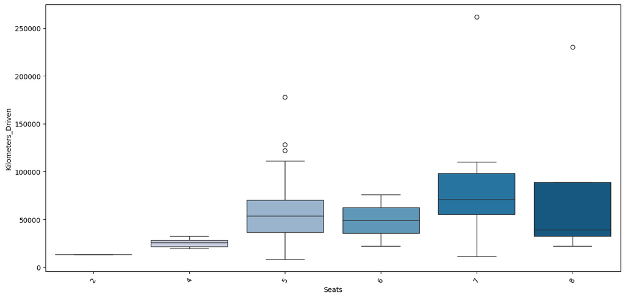

```python
# Relationship between food preparation time and cuisine type
plt.figure(figsize=(15,7))
sns.boxplot(x = "Seats", y = "Kilometers_Driven", data = df, palette = 'PuBu')
plt.xticks(rotation = 60)
plt.show()
```

##### Revenue generated by Segment

```python
plt.figure(figsize = (15, 7))
df.groupby(['Segment'])['price'].sum().sort_values(ascending = False).head(14)
```

```
Segment
luxury segment        5615.935
non-luxury segment    1362.720
Name: price, dtype: float64
```

##### Seats vs Power

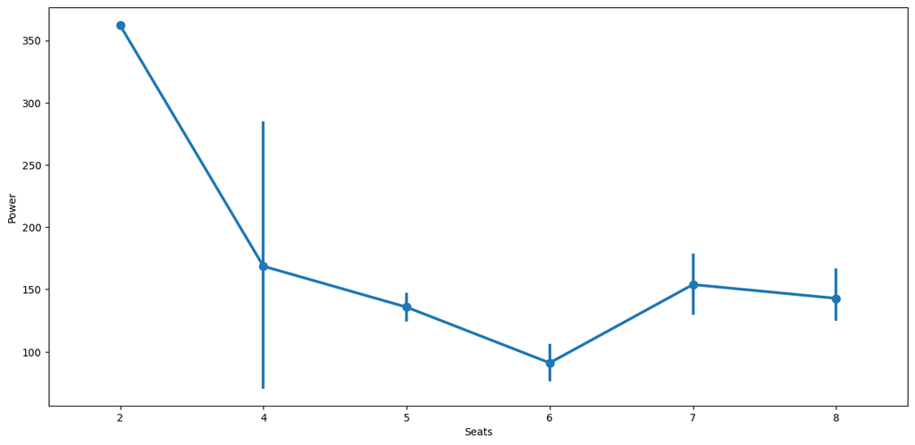

```python
# Relationship between rating and delivery time
plt.figure(figsize=(15, 7))
sns.pointplot(x = 'Seats', y = 'Power', data = df)
plt.show()
```

**Observations:**

- The point plot shows that 2‑seater cars have by far the highest average engine power, consistent with sports or performance-oriented vehicles that trade seating capacity for power.
- Average power drops sharply when moving from 2 to 4–6 seats, indicating that typical family cars prioritize efficiency over raw power.
- For larger vehicles (7–8 seats), average power rises again compared with 5–6 seaters, suggesting that bigger SUVs/MPVs require more power to move higher weight, even though they are not as extreme as 2‑seater sports cars.
- The error bars (if representing confidence intervals or standard error) are relatively wide for some seat counts, hinting at substantial variability in power within those categories and the need to consider additional features (e.g., segment, engine size) for finer-grained modeling.

##### Correlation among variables

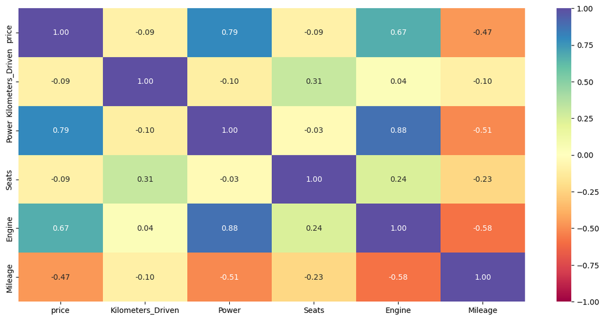

```python
# plot the heatmap
col_list = ['price', 'Kilometers_Driven', 'Power', 'Seats', 'Engine', 'Mileage']
plt.figure(figsize=(15, 7))
sns.heatmap(df[col_list].corr(), annot=True, vmin=-1, vmax=1, fmt=".2f", cmap="Spectral")
plt.show()
```

**Observations:**

### Compare price vs power by segment

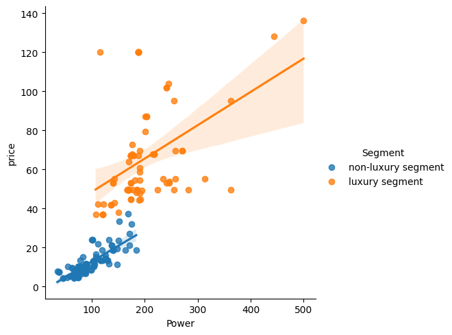

```python
lux = df[df["Segment"] == "luxury segment"]
non_lux = df[df["Segment"] == "non-luxury segment"]

sns.lmplot(data=df, x="Power", y="price", hue="Segment")
```

**Observations:**

- The scatterplot shows a strong positive relationship between Power and price in both segments:

as engine power increases, vehicle price generally rises.

- For a given power level, luxury cars are consistently priced much higher than non‑luxury cars,

indicating that Segment captures additional value beyond raw performance (brand, features, interior quality, etc.).

### **Conclusion and Recommendations**

##### What are your conclusions from the analysis? What recommendations would you like to share to help improve the business?

### Key conclusions from the analysis

1. **Segment is the primary price separator**
   - Luxury cars have a mean price more than 4× higher than non‑luxury cars and consistently sit in a much higher price band across all plots.
   - Even at similar power levels, luxury vehicles command a clear price premium, so brand/segment captures value beyond specs alone (features, finish, brand perception).
2. **Power and engine size are the strongest technical drivers of price**
   - Price has strong positive correlations with Power and Engine, and the scatterplots show price increasing steeply with power, especially in the luxury segment.
   - Engine and Power are highly collinear with each other, so they represent a single underlying performance factor that dominates technical pricing.
3. **Fuel efficiency trades off with performance and price**
   - Mileage is moderately negatively correlated with both Power and price: higher‑powered, more expensive cars tend to have worse mileage.
   - Most cars cluster around moderate mileage values, with a few very high‑efficiency or zero‑mileage points that behave like outliers or potential data‑quality issues.
4. **Usage (kilometers driven) and seating capacity matter less linearly, but highlight niches**
   - Kilometers_Driven shows weak linear correlation with price overall, but boxplots reveal high‑mileage outliers, especially among 7–8‑seater vehicles, suggesting heavy‑use fleet/people‑mover niches.
   - Seats has only weak correlation with price; it mainly segments usage patterns (e.g., powerful 2‑seater sports cars vs higher‑seater SUVs with moderate power).
5. **Distributions are skewed with influential outliers**
   - Price, power, engine size, and kilometers are all right‑skewed with a small number of very high values; these points can strongly influence simple linear models.
   - Log transforms and robust models (tree‑based, regularized regressions) are appropriate to handle skew and reduce outlier leverage.

### Business recommendations

1. **Design a segment‑aware pricing model**
   - Build separate or interaction‑aware models for luxury vs non‑luxury vehicles so that the system learns different price–power–engine relationships per segment.
   - Use Segment as a mandatory feature in the pricing API, and monitor segment‑level error (e.g., MAPE by segment) in your MLOps dashboards.
2. **Base core pricing on a performance–efficiency trade‑off**
   - Make Power/Engine the backbone of the price prediction, with Mileage acting as a moderating factor (higher power increases price; better mileage offsets operating‑cost concerns).
   - Expose this logic to sales teams as “explainable” features (e.g., “+X lakhs for each 50 BHP in this segment”), improving trust in automated prices.
3. **Handle outliers and special vehicles with explicit business rules**
   - Flag extreme values (very high price/power/engine, zero or extremely high mileage, unusually high kilometers for 7–8‑seat vehicles) as “special inventory” that requires manual review or separate pricing logic.
   - In the pipeline, implement data‑validation checks and automatic capping/winsorization so that rare outliers do not destabilize model training.
4. **Implement lifecycle‑ and usage‑aware adjustments**
   - Even though linear correlation is weak, use kilometer bands (e.g., `<30k`, `30–60k`, `60–100k`, `>100k`) to apply modest depreciation adjustments within the model or as post‑processing rules.
   - Track how error behaves across usage bands; if certain high‑mileage bands are systematically mispriced, introduce specific features or models for “high‑usage” inventory.
5. **Operationalize with strong MLOps and monitoring**
   - Ingest data from all dealership systems into a single, versioned feature store so the model always trains and serves on consistent definitions of Segment, Power, Mileage, etc.
   - Monitor:
     - Data drift for key drivers (distribution of Segment, Power, Engine, Mileage).
     - Performance drift (price prediction error by segment, by power band, by mileage band).
     - Business KPIs (gross margin, days‑to‑sale) before and after deploying the model.
6. **Use the model to support dynamic and competitive pricing**
   - Combine your internal model predictions with external market data (e.g., regional average prices for similar specs) to adjust list prices in near real time while preserving target margins.
   - Surface recommendations such as “undervalued/overvalued vehicles” and “priority to discount” lists to sales managers, turning the model into a daily decision tool rather than a one‑time estimator.